# Italian Olive - DV&R

Daniele Mensorio

# Data

```r
olive <- read.csv("~/Desktop/Università Daniele/Second Year/Data visulisation and reporting/LAB/data/olive.csv")
view(olive)
DT::datatable(olive)
```

|  | rownames | region | area | palmitic | palmitoleic | stearic | oleic | linoleic | linolenic | arachidic | eicosenoic |
| --- | --- | --- | --- | --- | --- | --- | --- | --- | --- | --- | --- |
| 1 | 1 | Southern Italy | North-Apulia | 10.75 | 0.75 | 2.26 | 78.23 | 6.72 | 0.36 | 0.6 | 0.29 |
| 2 | 2 | Southern Italy | North-Apulia | 10.88 | 0.73 | 2.24 | 77.09 | 7.81 | 0.31 | 0.61 | 0.29 |
| 3 | 3 | Southern Italy | North-Apulia | 9.11 | 0.54 | 2.46 | 81.13 | 5.49 | 0.31 | 0.63 | 0.29 |
| 4 | 4 | Southern Italy | North-Apulia | 9.66 | 0.57 | 2.4 | 79.52 | 6.19 | 0.5 | 0.78 | 0.35 |
| 5 | 5 | Southern Italy | North-Apulia | 10.51 | 0.67 | 2.59 | 77.71 | 6.72 | 0.5 | 0.8 | 0.46 |
| 6 | 6 | Southern Italy | North-Apulia | 9.11 | 0.49 | 2.68 | 79.24 | 6.78 | 0.51 | 0.7 | 0.44 |
| 7 | 7 | Southern Italy | North-Apulia | 9.22 | 0.66 | 2.64 | 79.9 | 6.18 | 0.49 | 0.56 | 0.29 |
| 8 | 8 | Southern Italy | North-Apulia | 11 | 0.61 | 2.35 | 77.28 | 7.34 | 0.39 | 0.64 | 0.35 |
| 9 | 9 | Southern Italy | North-Apulia | 10.82 | 0.6 | 2.39 | 77.45 | 7.09 | 0.46 | 0.83 | 0.33 |
| 10 | 10 | Southern Italy | North-Apulia | 10.37 | 0.55 | 2.13 | 79.44 | 6.33 | 0.26 | 0.52 | 0.3 |

[output cut: 562 more lines]

```r
#let's transform the 2 character variables (region and area) into a catgeorical variable
olive <- olive %>%
  mutate(region = as_factor(region),
         area = as_factor(area))
```

1. **Who collected the data**

The data was collected by Prof. Dr. Johann Gasteiger and Prof. Dr. Jure Zupan in *Neural networks in chemistry and drug design.*

2. **When was collected the data**

The data was collected on October 8, 1999

3. **To which aim was collected the data**

The main aim is a comparison of classification abilities of two different neural network methods, namely, back-propagation of errors and Kohonen learning, performed on a set of 572 Italian olive oils on the basis of an analysis of eight fatty acids.

4. **How many rows and how many variables (of what type)**

The data set contained 572 rows and 11 variables (columns).

Types of variable in the data-set:

- `rownames` Number of each row. (*integer variable*)
- `region` General region of Italy. (*character variable transformed into a categorical variable with levels* “`Southern Italy"`,”`Sardinia`” and “`Northern Italy`”)
- `area` Area of Italy. (*character variable transformed into a categorical variable with levels* “`North-Apulia`”, “`Calabria`”, “`South-Apulia`”, “`Sicily`” ,“`Inland-Sardinia`”, “`Coast-Sardinia`”, “`Umbria`”, “`East-Liguria`”, “`West-Liguria`”)
- `palmitic` Percent palmitic acid of sample. (*numeric variable*)
- `palmitoleic` Percent palmitoleic of sample. (*numeric variable*)
- `stearic` Percent stearic acid of sample. (*numeric variable*)
- `oleic` Percent oleic acid of sample. (*numeric variable*)
- `linoleic` Percent linoleic acid of sample. (*numeric variable*)
- `linolenic` Percent linolenic acid of sample. (*numeric variable*)
- `arachidic` Percent arachidic acid of sample. (*numeric variable*)
- `eicosenoic` Percent eicosenoic acid of sample. (*numeric variable*)
5. **What represents the rows**

Each observation represents an Italian olive oil.

6. **In what field of research of study have been employed the data**

The data have been employed in Computational Chemistry and Molecular Modeling.

# Missing Values

```r
sapply(olive, function(x) sum(is.na(x)))
```

```
##    rownames      region        area    palmitic palmitoleic     stearic
##           0           0           0           0           0           0
##       oleic    linoleic   linolenic   arachidic  eicosenoic
##           0           0           0           0           0
```

As seen in the table above, there is no missing value (i.e. na values) in the data-set.

# Outliers

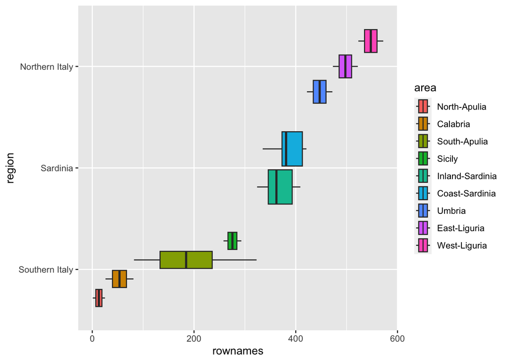

```r
ggplot(olive, aes(x = rownames, y = region, fill = area)) +
  geom_boxplot()
```

# Data summary

```r
print(dfSummary(olive,
                varnumbers   = FALSE,
                valid.col    = FALSE,
                graph.magnif = 0.76),
      method = 'render')
```

Data Frame Summary

olive

**Dimensions**: 572 x 11  
**Duplicates**: 0

| **Variable** | **Stats / Values** | **Freqs (% of Valid)** | **Graph** | **Missing** |
| --- | --- | --- | --- | --- |
| rownames [integer] | Mean (sd) : 286.5 (165.3) min ≤ med ≤ max: 1 ≤ 286.5 ≤ 572 IQR (CV) : 285.5 (0.6) | 572 distinct values (Integer sequence) |  | 0 (0.0%) |
| region [factor] | 1. Southern Italy 2. Sardinia 3. Northern Italy | 323 ( 56.5% ) 98 ( 17.1% ) 151 ( 26.4% ) |  | 0 (0.0%) |
| area [factor] | 1. North-Apulia 2. Calabria 3. South-Apulia 4. Sicily 5. Inland-Sardinia 6. Coast-Sardinia 7. Umbria 8. East-Liguria 9. West-Liguria | 25 ( 4.4% ) 56 ( 9.8% ) 206 ( 36.0% ) 36 ( 6.3% ) 65 ( 11.4% ) 33 ( 5.8% ) 51 ( 8.9% ) 50 ( 8.7% ) 50 ( 8.7% ) |  | 0 (0.0%) |
| palmitic [numeric] | Mean (sd) : 12.3 (1.7) min ≤ med ≤ max: 6.1 ≤ 12 ≤ 17.5 IQR (CV) : 2.7 (0.1) | 309 distinct values |  | 0 (0.0%) |
| palmitoleic [numeric] | Mean (sd) : 1.3 (0.5) min ≤ med ≤ max: 0.1 ≤ 1.1 ≤ 2.8 IQR (CV) : 0.8 (0.4) | 175 distinct values |  | 0 (0.0%) |
| stearic [numeric] | Mean (sd) : 2.3 (0.4) min ≤ med ≤ max: 1.5 ≤ 2.2 ≤ 3.8 IQR (CV) : 0.4 (0.2) | 138 distinct values |  | 0 (0.0%) |
| oleic [numeric] | Mean (sd) : 73.1 (4.1) min ≤ med ≤ max: 63 ≤ 73 ≤ 84.1 IQR (CV) : 6.8 (0.1) | 389 distinct values |  | 0 (0.0%) |
| linoleic [numeric] | Mean (sd) : 9.8 (2.4) min ≤ med ≤ max: 4.5 ≤ 10.3 ≤ 14.7 IQR (CV) : 4.1 (0.2) | 344 distinct values |  | 0 (0.0%) |
| linolenic [numeric] | Mean (sd) : 0.3 (0.1) min ≤ med ≤ max: 0 ≤ 0.3 ≤ 0.7 IQR (CV) : 0.1 (0.4) | 45 distinct values |  | 0 (0.0%) |
| arachidic [numeric] | Mean (sd) : 0.6 (0.2) min ≤ med ≤ max: 0 ≤ 0.6 ≤ 1 IQR (CV) : 0.2 (0.4) | 76 distinct values |  | 0 (0.0%) |
| eicosenoic [numeric] | Mean (sd) : 0.2 (0.1) min ≤ med ≤ max: 0 ≤ 0.2 ≤ 0.6 IQR (CV) : 0.3 (0.9) | 44 distinct values |  | 0 (0.0%) |

Generated by summarytools 1.0.1 ([R](https://www.r-project.org/) version 4.3.1)  
2023-12-15

# Composition plot by region and area

```r
Pie_data <- olive %>%
  group_by(region) %>%
  summarise(n = n(),.groups = 'drop') %>%
  mutate(perc=round(100*n/sum(n),1))
datatable(Pie_data)
```

|  | region | n | perc |
| --- | --- | --- | --- |
| 1 | Southern Italy | 323 | 56.5 |
| 2 | Sardinia | 98 | 17.1 |
| 3 | Northern Italy | 151 | 26.4 |

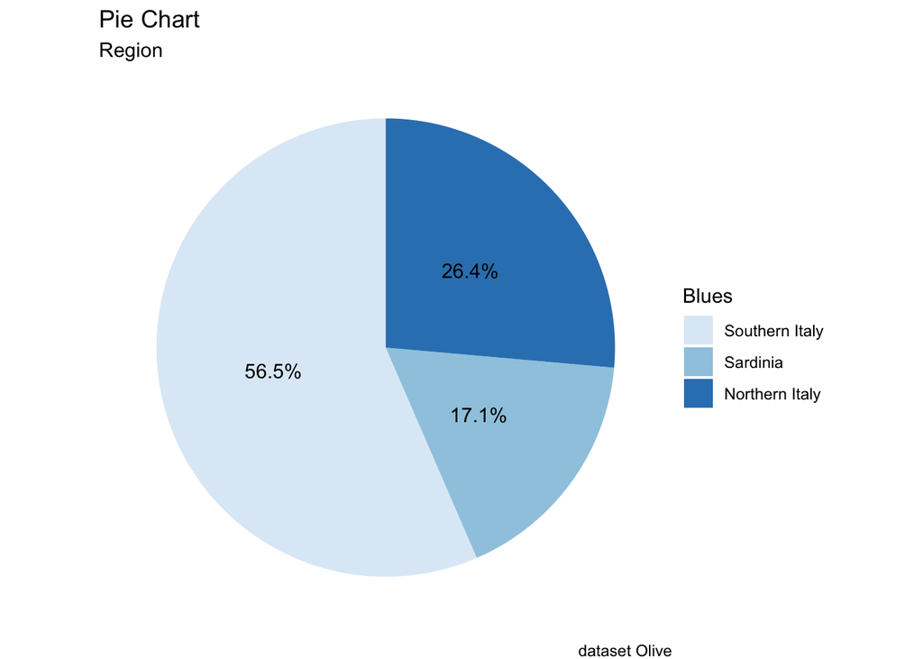

```r
Pie_data %>%
  ggplot(aes(x="",y=perc, fill=region)) +
  geom_bar(width = 1,stat="identity") +
  geom_text(aes(label = paste0(perc,"%")),
            position=position_stack(0.5)) +
  scale_fill_brewer("Blues") +
  coord_polar("y", start=0) +
  theme_void() +
  labs(title="Pie Chart", subtitle = "Region", caption= "dataset Olive")
```

```r
Pie_data <- olive %>%
  group_by(area) %>%
  summarise(n = n(),.groups = 'drop') %>%
  mutate(perc=round(100*n/sum(n),1))
datatable(Pie_data)
```

|  | area | n | perc |
| --- | --- | --- | --- |
| 1 | North-Apulia | 25 | 4.4 |
| 2 | Calabria | 56 | 9.8 |
| 3 | South-Apulia | 206 | 36 |
| 4 | Sicily | 36 | 6.3 |
| 5 | Inland-Sardinia | 65 | 11.4 |
| 6 | Coast-Sardinia | 33 | 5.8 |
| 7 | Umbria | 51 | 8.9 |
| 8 | East-Liguria | 50 | 8.7 |
| 9 | West-Liguria | 50 | 8.7 |

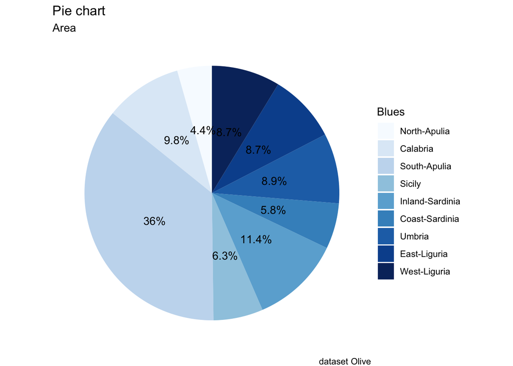

```r
Pie_data %>%
  ggplot(aes(x="",y=perc, fill=area)) +
  geom_bar(width = 1,stat="identity") +
  geom_text(aes(label = paste0(perc,"%")),
            position=position_stack(0.5)) +
  scale_fill_brewer("Blues") +
  coord_polar("y", start=0) +
  theme_void() +
  labs(title="Pie chart", subtitle = "Area", caption= "dataset Olive")
```

```r
DATA1 <- olive %>%
  group_by(region, area) %>%
  summarise(n = n(),.groups = 'drop')
p1 <- treemap(DATA1,
             index=c("region", "area"),
             vSize="n",
             type="index",
             palette = "Set2",
             bg.labels=c("white"),
             align.labels=list(
               c("center", "center"),
               c("right", "bottom")
             )
           )
```

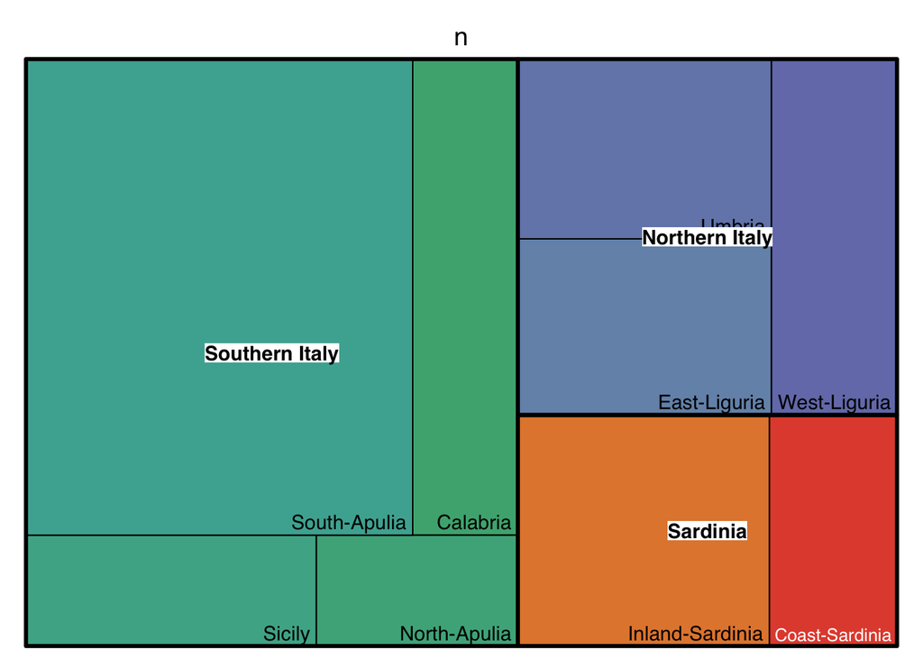

```r
d3tree2(p1 ,  rootname = "General" )
```

[interactive chart not shown]

# Composition of fatty acid into olive oil

```r
data1 <- olive %>%
  summarise(palmitic = (sum(palmitic)/n()),
            palmitoleic = (sum(palmitoleic)/n()),
            stearic = (sum(stearic)/n()),
            oleic = (sum(oleic)/n()),
            linoleic = (sum(linoleic)/n()),
            linolenic = (sum(linolenic)/n()),
            arachidic = (sum(arachidic)/n()),
            eicosenoic = (sum(eicosenoic)/n()), .groups = "drop")
datatable(data1)
```

|  | palmitic | palmitoleic | stearic | oleic | linoleic | linolenic | arachidic | eicosenoic |
| --- | --- | --- | --- | --- | --- | --- | --- | --- |
| 1 | 12.31741258741258 | 1.260944055944055 | 2.288653846153848 | 73.11748251748247 | 9.805279720279733 | 0.3188811188811186 | 0.5809790209790215 | 0.1628146853146853 |

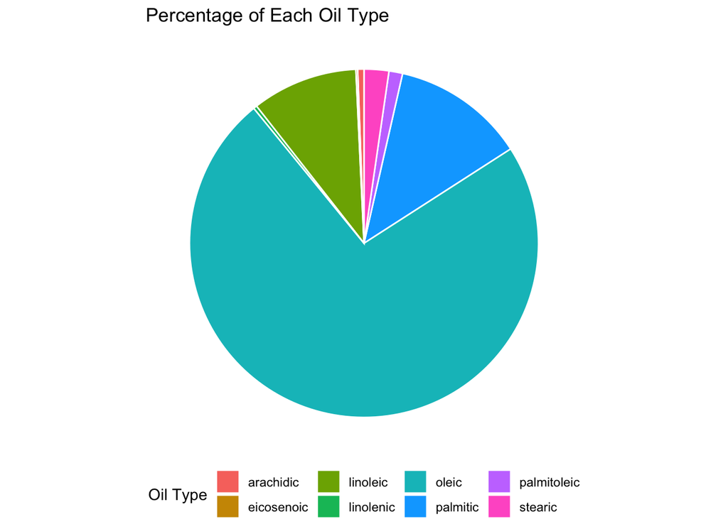

```r
data1_long <- gather(data1, key = "Oil", value = "Percentage")
ggplot(data1_long, aes(x = "", y = Percentage, fill = Oil)) +
  geom_bar(stat = "identity", width = 1, color = "white") +
  coord_polar("y") +
  theme_minimal() +
  theme_void() +
  labs(title = "Percentage of Each Oil Type",
       fill = "Oil Type") +
  theme(legend.position = "bottom")
```

# Composition of fatty oils into olive oil filtered by region

```r
data2 <- olive %>%
  group_by(region) %>%
  summarise(palmitic = (sum(palmitic)/n()),
            palmitoleic = (sum(palmitoleic)/n()),
            stearic = (sum(stearic)/n()),
            oleic = (sum(oleic)/n()),
            linoleic = (sum(linoleic)/n()),
            linolenic = (sum(linolenic)/n()),
            arachidic = (sum(arachidic)/n()),
            eicosenoic = (sum(eicosenoic)/n()), .groups = "drop")
datatable(data2)
```

|  | region | palmitic | palmitoleic | stearic | oleic | linoleic | linolenic | arachidic | eicosenoic |
| --- | --- | --- | --- | --- | --- | --- | --- | --- | --- |
| 1 | Southern Italy | 13.32287925696594 | 1.548018575851394 | 2.287739938080495 | 71.00009287925695 | 10.33498452012383 | 0.3806501547987616 | 0.6311764705882354 | 0.2732198142414861 |
| 2 | Sardinia | 11.1134693877551 | 0.9674489795918367 | 2.261836734693878 | 72.68020408163267 | 11.96530612244898 | 0.2709183673469387 | 0.731734693877551 | 0.01938775510204083 |
| 3 | Northern Italy | 10.94801324503311 | 0.8373509933774839 | 2.308013245033112 | 77.93052980132452 | 7.270331125827814 | 0.217880794701987 | 0.3757615894039737 | 0.01973509933774833 |

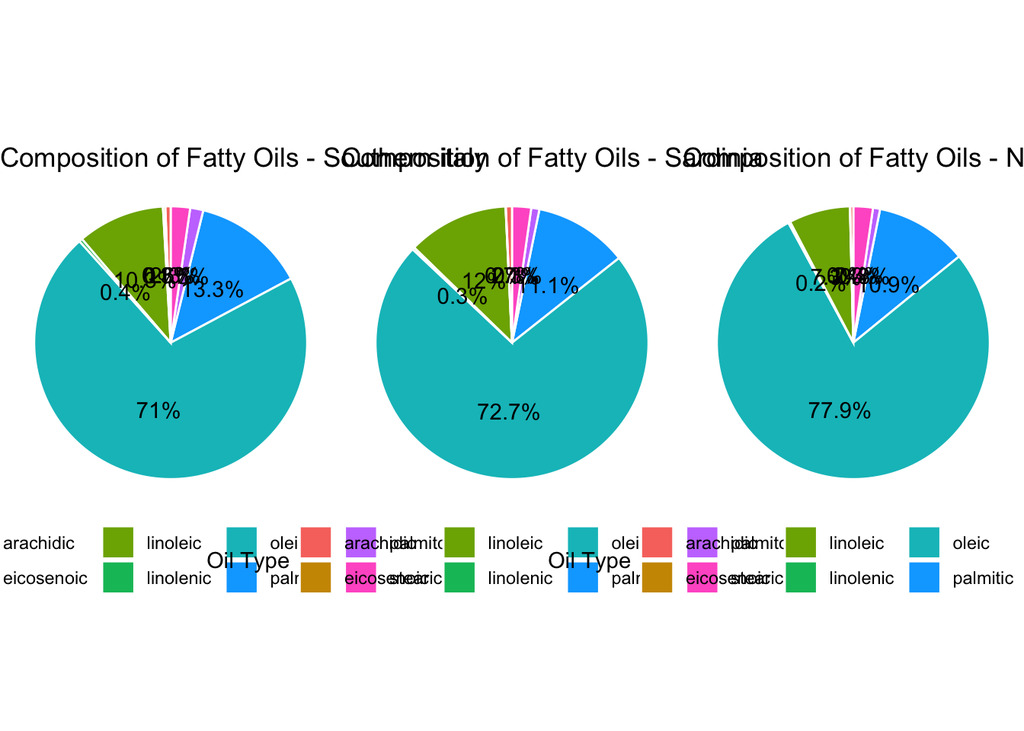

```r
plot1 <- data2 %>%
  filter(region == "Southern Italy") %>%
  gather(key = "variable", value = "value", -region)
pc1 <- ggplot(plot1, aes(x = factor(1), y = value, fill = variable)) +
  geom_bar(stat = "identity", width = 1, color = "white") +
  coord_polar("y") +
  theme_minimal() +
  theme_void() +
  labs(title = "Composition of Fatty Oils - Southern italy", fill = "Oil Type") +
  theme(legend.position = "bottom") +
  theme(axis.text = element_blank(), axis.title = element_blank()) +
  geom_text(aes(label = paste0(round(value, 1), "%")), position = position_stack(vjust = 0.5))
plot2 <- data2 %>%
  filter(region == "Sardinia") %>%
  gather(key = "variable", value = "value", -region)
pc2 <- ggplot(plot2, aes(x = factor(1), y = value, fill = variable)) +
  geom_bar(stat = "identity", width = 1, color = "white") +
  coord_polar("y") +
  theme_minimal() +
  theme_void() +
  labs(title = "Composition of Fatty Oils - Sardinia", fill = "Oil Type") +
  theme(legend.position = "bottom") +
  theme(axis.text = element_blank(), axis.title = element_blank()) +
  geom_text(aes(label = paste0(round(value, 1), "%")), position = position_stack(vjust = 0.5))
plot3 <- data2 %>%
  filter(region == "Northern Italy") %>%
  gather(key = "variable", value = "value", -region)
pc3 <- ggplot(plot3, aes(x = factor(1), y = value, fill = variable)) +
  geom_bar(stat = "identity", width = 1, color = "white") +
  coord_polar("y") +
  theme_minimal() +
  theme_void() +
  labs(title = "Composition of Fatty Oils - Northern Italy", fill = "Oil Type") +
  theme(legend.position = "bottom") +
  theme(axis.text = element_blank(), axis.title = element_blank()) +
  geom_text(aes(label = paste0(round(value, 1), "%")), position = position_stack(vjust = 0.5))
ggarrange(pc1, pc2, pc3, ncol = 3)
```

# Composition of fatty oils into olive oil filtered by area

```r
data7 <- olive %>%
  group_by(region, area) %>%
  summarise(palmitic = (sum(palmitic)/n()),
            palmitoleic = (sum(palmitoleic)/n()),
            stearic = (sum(stearic)/n()),
            oleic = (sum(oleic)/n()),
            linoleic = (sum(linoleic)/n()),
            linolenic = (sum(linolenic)/n()),
            arachidic = (sum(arachidic)/n()),
            eicosenoic = (sum(eicosenoic)/n()), .groups = "drop")
datatable(data7)
```

|  | region | area | palmitic | palmitoleic | stearic | oleic | linoleic | linolenic | arachidic | eicosenoic |
| --- | --- | --- | --- | --- | --- | --- | --- | --- | --- | --- |
| 1 | Southern Italy | North-Apulia | 10.27 | 0.616 | 2.3484 | 78.20400000000001 | 7.058399999999999 | 0.4256000000000001 | 0.7195999999999998 | 0.3456000000000001 |
| 2 | Southern Italy | Calabria | 13.02232142857143 | 1.213571428571429 | 2.625178571428572 | 73.07178571428571 | 8.19 | 0.4557142857142856 | 0.6362499999999999 | 0.2832142857142857 |
| 3 | Southern Italy | South-Apulia | 13.95669902912622 | 1.839223300970875 | 2.109805825242718 | 69.11208737864078 | 11.66310679611651 | 0.3470873786407767 | 0.5973300970873786 | 0.2422815533980584 |
| 4 | Southern Italy | Sicily | 12.28361111111111 | 1.049166666666667 | 2.738888888888889 | 73.57833333333333 | 8.347222222222221 | 0.4247222222222222 | 0.7555555555555556 | 0.3844444444444446 |
| 5 | Sardinia | Inland-Sardinia | 10.97723076923076 | 0.9455384615384617 | 2.172307692307692 | 73.60538461538461 | 11.25076923076923 | 0.2878461538461539 | 0.7378461538461538 | 0.01969230769230771 |
| 6 | Sardinia | Coast-Sardinia | 11.38181818181818 | 1.010606060606061 | 2.438181818181818 | 70.85787878787879 | 13.37272727272727 | 0.2375757575757576 | 0.71969696969697 | 0.0187878787878788 |
| 7 | Northern Italy | Umbria | 10.86372549019608 | 0.5988235294117648 | 1.943333333333333 | 79.55705882352943 | 5.970980392156862 | 0.3411764705882352 | 0.4243137254901961 | 0.01980392156862746 |
| 8 | Northern Italy | East-Liguria | 11.454 | 0.8419999999999997 | 2.414000000000001 | 77.45999999999998 | 6.894 | 0.264 | 0.636 | 0.01880000000000001 |
| 9 | Northern Italy | West-Liguria | 10.528 | 1.076 | 2.574 | 76.74199999999998 | 8.972000000000001 | 0.04600000000000001 | 0.06600000000000004 | 0.02060000000000001 |

[figure not shown]

```r
plot1 <- data7 %>%
  filter(area == "North-Apulia") %>%
  gather(key = "fatty_acid", value = "value", -region, -area)
pc1 <- ggplot(plot1, aes(x = factor(1), y = value, fill = fatty_acid)) +
  geom_bar(stat = "identity", width = 1, color = "white") +
  coord_polar("y") +
  theme_minimal() +
  theme_void() +
  theme(legend.position = "left") +
  labs(title = "Composition of Fatty Oils - North-Apulia", fill = "Oil Type") +
  theme(axis.text = element_blank(), axis.title = element_blank()) +
  geom_text(aes(label = paste0(round(value, 1), "%")), position = position_stack(vjust = 0.5))
plot2 <- data7 %>%
  filter(area == "Calabria") %>%
  gather(key = "fatty_acid", value = "value", -region, -area)
pc2 <- ggplot(plot2, aes(x = factor(1), y = value, fill = fatty_acid)) +
  geom_bar(stat = "identity", width = 1, color = "white") +
  coord_polar("y") +
  theme_minimal() +
  theme_void() +
  theme(legend.position = "none") +
  labs(title = "Composition of Fatty Oils - Calabria", fill = "Oil Type") +
  theme(axis.text = element_blank(), axis.title = element_blank()) +
  geom_text(aes(label = paste0(round(value, 1), "%")), position = position_stack(vjust = 0.5))
plot3 <- data7 %>%
  filter(area == "South-Apulia") %>%
  gather(key = "fatty_acid", value = "value", -region, -area)
pc3 <- ggplot(plot3, aes(x = factor(1), y = value, fill = fatty_acid)) +
  geom_bar(stat = "identity", width = 1, color = "white") +
  coord_polar("y") +
  theme_minimal() +
  theme_void() +
  theme(legend.position = "none") +
  labs(title = "Composition of Fatty Oils - South-Apulia", fill = "Oil Type") +
  theme(axis.text = element_blank(), axis.title = element_blank()) +
  geom_text(aes(label = paste0(round(value, 1), "%")), position = position_stack(vjust = 0.5))
plot4 <- data7 %>%
  filter(area == "Sicily") %>%
  gather(key = "fatty_acid", value = "value", -region, -area)
pc4 <- ggplot(plot4, aes(x = factor(1), y = value, fill = fatty_acid)) +
  geom_bar(stat = "identity", width = 1, color = "white") +
  coord_polar("y") +
  theme_minimal() +
  theme_void() +
  theme(legend.position = "none") +
  labs(title = "Composition of Fatty Oils - Sicily", fill = "Oil Type") +
  theme(axis.text = element_blank(), axis.title = element_blank()) +
  geom_text(aes(label = paste0(round(value, 1), "%")), position = position_stack(vjust = 0.5))


plot5 <- data7 %>%
  filter(area == "Inland-Sardinia") %>%
  gather(key = "fatty_acid", value = "value", -region, -area)
pc5 <- ggplot(plot5, aes(x = factor(1), y = value, fill = fatty_acid)) +
  geom_bar(stat = "identity", width = 1, color = "white") +
  coord_polar("y") +
  theme_minimal() +
  theme_void() +
  theme(legend.position = "none") +
  labs(title = "Composition of Fatty Oils - Inland-Sardinia", fill = "Oil Type") +
  theme(axis.text = element_blank(), axis.title = element_blank()) +
  geom_text(aes(label = paste0(round(value, 1), "%")), position = position_stack(vjust = 0.5))
plot6 <- data7 %>%
  filter(area == "Coast-Sardinia") %>%
  gather(key = "fatty_acid", value = "value", -region, -area)
pc6 <- ggplot(plot6, aes(x = factor(1), y = value, fill = fatty_acid)) +
  geom_bar(stat = "identity", width = 1, color = "white") +
  coord_polar("y") +
  theme_minimal() +
  theme_void() +
  theme(legend.position = "none") +
  labs(title = "Composition of Fatty Oils - Coast-Sardinia", fill = "Oil Type") +
  theme(axis.text = element_blank(), axis.title = element_blank()) +
  geom_text(aes(label = paste0(round(value, 1), "%")), position = position_stack(vjust = 0.5))


plot7 <- data7 %>%
  filter(area == "Umbria") %>%
  gather(key = "fatty_acid", value = "value", -region, -area)
pc7 <- ggplot(plot7, aes(x = factor(1), y = value, fill = fatty_acid)) +
  geom_bar(stat = "identity", width = 1, color = "white") +
  coord_polar("y") +
  theme_minimal() +
  theme_void() +
  theme(legend.position = "none") +
  labs(title = "Composition of Fatty Oils - Umbria", fill = "Oil Type") +
  theme(axis.text = element_blank(), axis.title = element_blank()) +
  geom_text(aes(label = paste0(round(value, 1), "%")), position = position_stack(vjust = 0.5))
plot8 <- data7 %>%
  filter(area == "East-Liguria") %>%
  gather(key = "fatty_acid", value = "value", -region, -area)
pc8 <- ggplot(plot8, aes(x = factor(1), y = value, fill = fatty_acid)) +
  geom_bar(stat = "identity", width = 1, color = "white") +
  coord_polar("y") +
  theme_minimal() +
  theme_void() +
  theme(legend.position = "none") +
  labs(title = "Composition of Fatty Oils - East-Liguria", fill = "Oil Type") +
  theme(axis.text = element_blank(), axis.title = element_blank()) +
  geom_text(aes(label = paste0(round(value, 1), "%")), position = position_stack(vjust = 0.5))
plot9 <- data7 %>%
  filter(area == "West-Liguria") %>%
  gather(key = "fatty_acid", value = "value", -region, -area)
pc9 <- ggplot(plot7, aes(x = factor(1), y = value, fill = fatty_acid)) +
  geom_bar(stat = "identity", width = 1, color = "white") +
  coord_polar("y") +
  theme_minimal() +
  theme_void() +
  theme(legend.position = "none") +
  labs(title = "Composition of Fatty Oils - West-Liguria", fill = "Oil Type") +
  theme(axis.text = element_blank(), axis.title = element_blank()) +
  geom_text(aes(label = paste0(round(value, 1), "%")), position = position_stack(vjust = 0.5))

plots_list <- list(pc1, pc2, pc3, pc4, pc5, pc6, pc7, pc8, pc9)
grid.arrange(grobs = plots_list, nrow = 3, common.legend = TRUE, legend = "right", align = "hv")
```